# R Notebook

# Linear Regression in R

## Create a dataset

```r
mouse.data <- data.frame(
  weight = c(0.9, 1.8, 2.4, 3.5, 3.9, 4.4, 5.1, 5.6, 6.3),
  size = c(1.4,2.6, 1.0, 3.7, 5.5, 3.2, 3.0, 4.9, 6.3)
)
mouse.data
```

| weight | size |
| --- | --- |
| 0.9 | 1.4 |
| 1.8 | 2.6 |
| 2.4 | 1.0 |
| 3.5 | 3.7 |
| 3.9 | 5.5 |
| 4.4 | 3.2 |
| 5.1 | 3.0 |
| 5.6 | 4.9 |
| 6.3 | 6.3 |

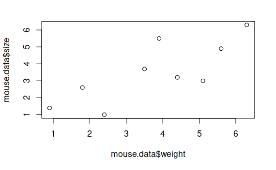

```r
plot(mouse.data$weight, mouse.data$size)
```

## Generate the regression

```r
mouse.regression <- lm(size ~ weight, data = mouse.data)
summary(mouse.regression)
```

```
Call:
lm(formula = size ~ weight, data = mouse.data)

Residuals:
    Min      1Q  Median      3Q     Max
-1.5482 -0.8037  0.1186  0.6186  1.8852

Coefficients:
            Estimate Std. Error t value Pr(>|t|)
(Intercept)   0.5813     0.9647   0.603   0.5658
weight        0.7778     0.2334   3.332   0.0126 *
---
Signif. codes:  0 ‘***’ 0.001 ‘**’ 0.01 ‘*’ 0.05 ‘.’ 0.1 ‘ ’ 1

Residual standard error: 1.19 on 7 degrees of freedom
Multiple R-squared:  0.6133,    Adjusted R-squared:  0.558
F-statistic:  11.1 on 1 and 7 DF,  p-value: 0.01256
```

- **Residuals**: Summary of residuals (distance from data to fitted line). Ideally they should be symmetrically distributed about the line
- **Coefficients**: Estimate gives the slope and intercept for the fitted lined. Std. Error and t-value give information as to how the p-values are calculated.The final column gives the p-values, of which the slope is the important one and should be less than 0.05
- **Signif. codes**: Provides a ‘legend’ for the mark after the p-value.In this case the * shows that the value is below 0.05.
- **Residual standard error**: The square root of the denominator in the formula for **F**
- **Multiple R-squared**: This is $R^2$, in this case showing that 61% of variation in size is based on weight
- **Adjusted R-squared**: $R^2$ scaled by the number of parameters in the model
- **F-statistic**: The value for $F$ and the degrees of freedom
- **p-value**: p-value

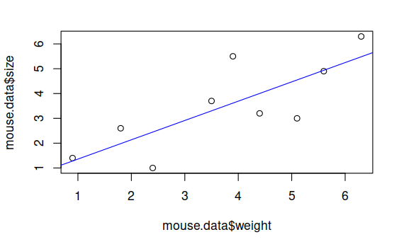

```r
plot(mouse.data$weight, mouse.data$size)
abline(mouse.regression, col = 'blue')
```